# Recommendation System (collaborative)

## Problem Statement: You are the sales manager for “BeerMart”, an online beer store in the United States. You want to build a recommendation system (collaborative) for your store, where customers will be recommended the beer that they are most likely to buy

```r
#Installing Packages
suppressWarnings({ ## Supressing Warning messages
  suppressPackageStartupMessages({ ## Supressing startup messages
    library(dplyr)
    library(data.table)
    library(ggplot2)
    library(recommenderlab)
    library(reshape2)
    library(Matrix)
  })
})
```

# 1) Reading Dataset

```r
#Importing datasets
beer_data <- read.csv('./beer_data.csv',na.strings = "")
print(dim(beer_data))
```

```
## [1] 475984      3
```

```r
#Checking for duplicates
beer_data <- unique(beer_data)
print(dim(beer_data))
```

```
## [1] 475404      3
```

```r
#Print summary
summary(beer_data)
```

```
##   beer_beerid         review_profilename review_overall
##  Min.   :    3   northyorksammy:  1844   Min.   :0.000
##  1st Qu.: 1716   mikesgroove   :  1377   1st Qu.:3.500
##  Median :13896   BuckeyeNation :  1337   Median :4.000
##  Mean   :21663   Thorpe429     :  1072   Mean   :3.814
##  3rd Qu.:39397   ChainGangGuy  :  1046   3rd Qu.:4.500
##  Max.   :77317   (Other)       :468628   Max.   :5.000
##                  NA's          :   100
```

# 2) Exploration-

### How are ratings distributed?

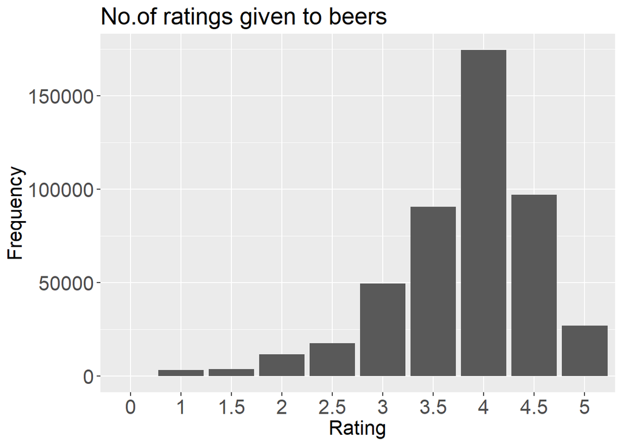

```r
ggplot(data = beer_data, aes(x = factor(review_overall))) +
  geom_bar() +
  labs(title="No.of ratings given to beers", x="Rating", y="Frequency") +
  theme(text = element_text(size=16),axis.text = element_text(size=16))
```

### Distribution of Average rating by user?

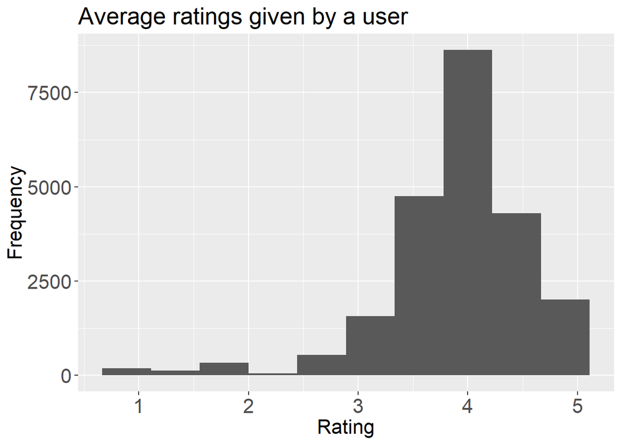

```r
x <- beer_data %>%
  group_by(review_profilename) %>%
  summarise(ratings_mean = mean(review_overall))
##How are rating distributed
ggplot(data = x, aes(x = ratings_mean)) +
  geom_histogram(bins = 10) +
  labs(title="Average ratings given by a user", x="Rating", y="Frequency") +
  theme(text = element_text(size=16),axis.text = element_text(size=16))
```

Most people rate beer highly.

### Distribution of nummber of rating given to a beer?

```r
beer_wise_count <- beer_data %>%
  group_by(beer_beerid) %>%
  summarise(rating_count = length(review_overall))

summary(beer_wise_count)
```

```
##   beer_beerid     rating_count
##  Min.   :    3   Min.   :  1.00
##  1st Qu.:16879   1st Qu.:  1.00
##  Median :37362   Median :  2.00
##  Mean   :36972   Mean   : 11.79
##  3rd Qu.:56232   3rd Qu.:  5.00
##  Max.   :77317   Max.   :980.00
```

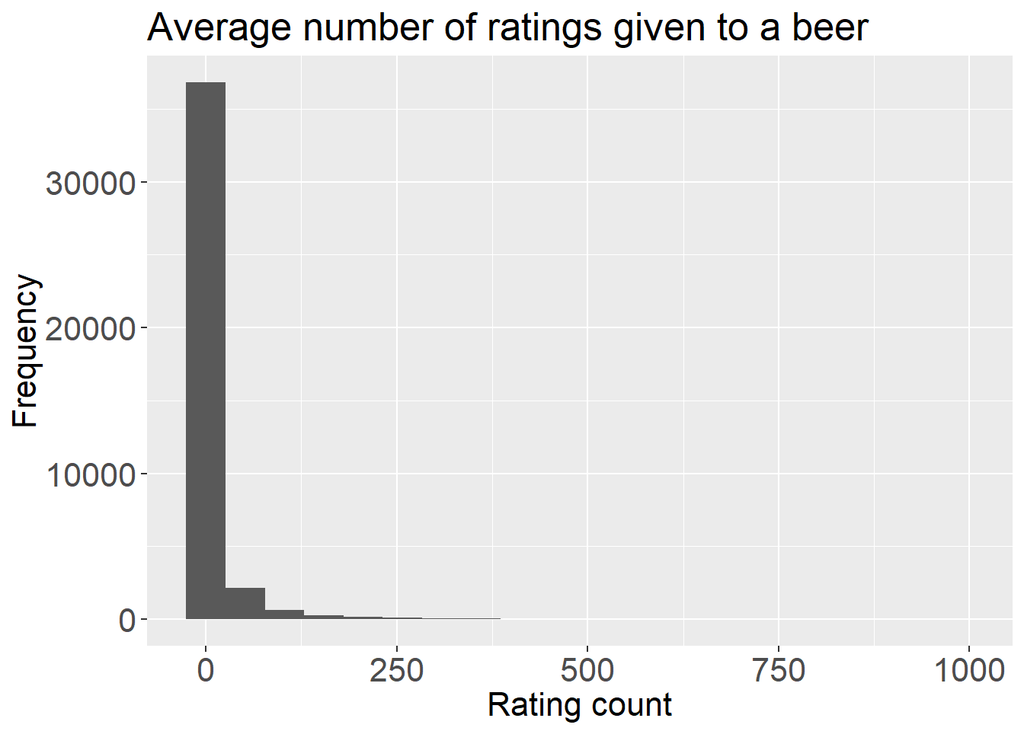

```r
ggplot(data= beer_wise_count,aes(x=rating_count)) +
  geom_histogram(bins = 20) +
  labs(title="Average number of ratings given to a beer", x="Rating count", y="Frequency") +
  theme(text = element_text(size=16),axis.text = element_text(size=16))
```

### Distribution of average number of rating given by a user?

```r
review_profilename_count <- beer_data %>%
  group_by(review_profilename) %>%
  summarise(rating_count = length(review_overall))

summary(review_profilename_count)
```

```
##    review_profilename  rating_count
##  0110x011   :    1    Min.   :   1.00
##  01Ryan10   :    1    1st Qu.:   1.00
##  03SVTCobra :    1    Median :   3.00
##  04101Brewer:    1    Mean   :  21.13
##  05Harley   :    1    3rd Qu.:  11.00
##  (Other)    :22492    Max.   :1844.00
##  NA's       :    1
```

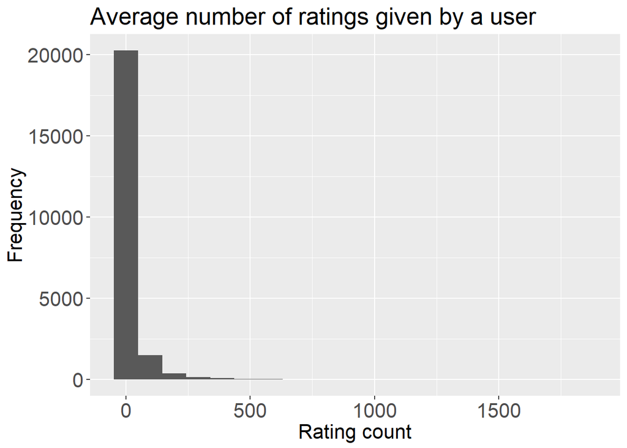

```r
ggplot(data= review_profilename_count,aes(x=rating_count)) +
  geom_histogram(bins = 20) +
  labs(title="Average number of ratings given by a user", x="Rating count", y="Frequency") +
  theme(text = element_text(size=16),axis.text = element_text(size=16))
```

### As we can see that only some beers have been rated many times while 75% of beer have less than 5 ratings. We will only use beers which atleast have more than 100 rating count. Let’s check how much beers we would be convering.

```r
sprintf('Coverage : %s%%',round(sum(beer_wise_count$rating_count >= 100)*100 / nrow(beer_wise_count),2))
```

```
## [1] "Coverage : 2.53%"
```

There are 2.53% of beers which have more than 100 ratings and we would be only interested in them. Recommender systems suffer with the problem of cold start and 100 is a good number to give appropriate recommendation. Let’s filter our data for only these beers.

```r
beer_of_interest <- beer_wise_count[beer_wise_count$rating_count >= 100,'beer_beerid']

beer_data_filter <- merge(beer_data, beer_of_interest, by = 'beer_beerid')

sprintf('Drop in observations : %s%%',(round(100 - (nrow(beer_data_filter)*100/nrow(beer_data)),2)))
```

```
## [1] "Drop in observations : 53.1%"
```

### As we can see by only taking 2.53% of beers recommendation we only loose 53.1% of rating data. Also filter users who have rated more than 10 ratings

```r
review_profilename_count <- beer_data_filter %>%
  group_by(review_profilename) %>%
  summarise(rating_count = length(review_overall))

user_of_interest <- review_profilename_count[review_profilename_count$rating_count > 10,'review_profilename']

beer_data_filter <- merge(beer_data_filter, user_of_interest, by = 'review_profilename')

sprintf('Drop in observations : %s%%',(round(100 - (nrow(beer_data_filter)*100/nrow(beer_data)),2)))
```

```
## [1] "Drop in observations : 60.8%"
```

### OVerall drop in data is 60.8%

```r
#Removing observations with no username
beer_data_filter <- beer_data_filter[!is.na(beer_data_filter$review_profilename),]

#This step will take a lot of time and memory
beer_data_filter1 <- acast(beer_data_filter, review_profilename ~ beer_beerid,value.var = 'review_overall',fun.aggregate=mean)

#Converting NaN to zero
beer_data_filter1[is.na(beer_data_filter1) ] = 0

## Making a sparse matrix
rating_matrix <- Matrix(beer_data_filter1,sparse = TRUE)
print(dim(rating_matrix))
```

```
## [1] 4336 1020
```

### That means 4336 users and 1020 beers. Now to convert the sparse matrix to a real rating matrix.

```r
real_matrix <- new("realRatingMatrix", data = rating_matrix)
```

### Let’s visualize similarity between users and items

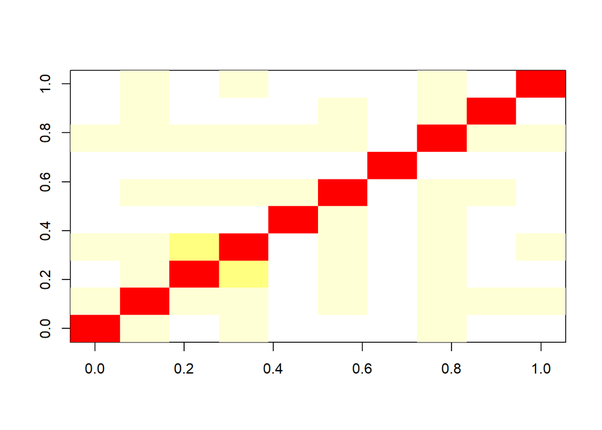

```r
#First 10 users
image(as.matrix(similarity(real_matrix[1:10,],method = 'cosine',which = 'users')))
```

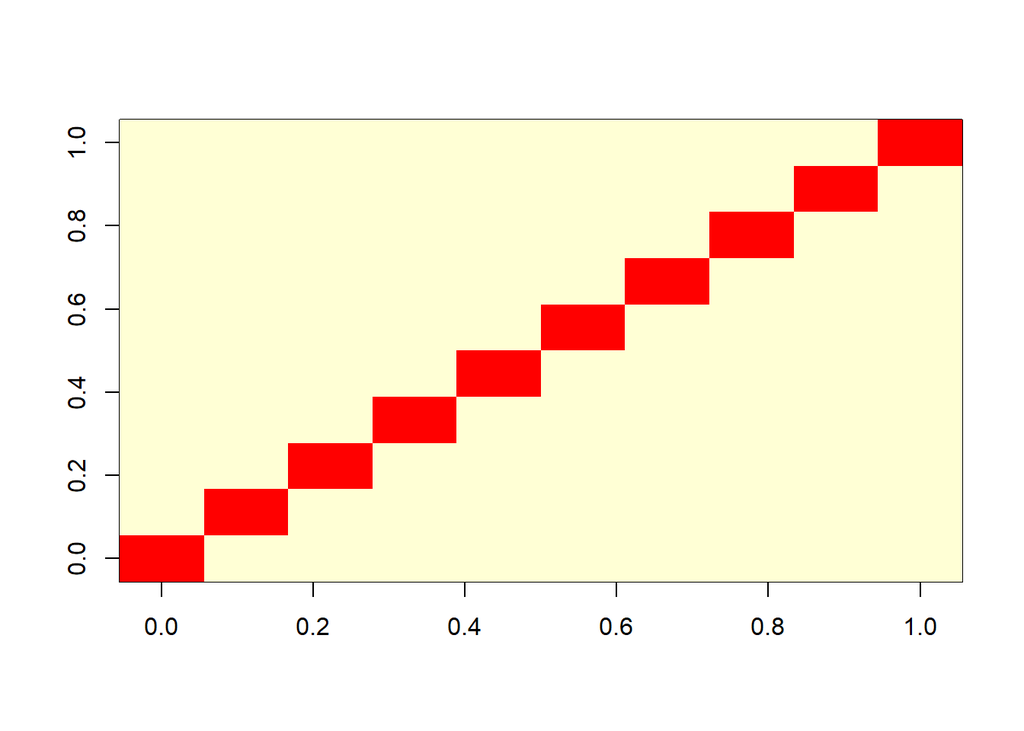

```r
#First 10 items
image(as.matrix(similarity(real_matrix[,1:10],method = 'cosine',which = 'items')))
```

## Split Validation

```r
# Making evaluation data set with 80 - 20 splot
eval_sets <- evaluationScheme(real_matrix, method = "split",train = 0.8, given = 10,goodRating = 3)

#Defining models to be evaluated
models <- list(
IBCF_cos = list(name = "IBCF",parameter = NULL),
UBCF_cos = list(name = "UBCF",parameter = NULL)
)

#evaluation
eval_results <- evaluate(x = eval_sets,method = models,n=seq(1,19,2))
```

```
## IBCF run fold/sample [model time/prediction time]
##   1  [25.97sec/0.9sec]
## UBCF run fold/sample [model time/prediction time]
##   1  [0.01sec/25sec]
```

```r
#Printing Model performance
print(eval_results$IBCF_cos@results[[1]])
```

```
## An object of class "confusionMatrix"
## Slot "cm":
##           TP         FP       FN       TN  precision      recall
## 1  0.0437788  0.9562212 32.30184 976.6982 0.04377880 0.001765491
## 3  0.1232719  2.8721198 32.22235 974.7823 0.04109063 0.005245439
## 5  0.1993088  4.7857143 32.14631 972.8687 0.03986175 0.007817590
## 7  0.2764977  6.6912442 32.06912 970.9631 0.03952710 0.009714067
## 9  0.3410138  8.6036866 32.00461 969.0507 0.03795443 0.011032468
## 11 0.4112903 10.5069124 31.93433 967.1475 0.03747731 0.013615831
## 13 0.4654378 12.4216590 31.88018 965.2327 0.03590630 0.015439086
## 15 0.5138249 14.3364055 31.83180 963.3180 0.03437020 0.016383405
## 17 0.5725806 16.2384793 31.77304 961.4159 0.03382353 0.018116205
## 19 0.6336406 18.1359447 31.71198 959.5184 0.03351322 0.020146162
##            TPR          FPR
## 1  0.001765491 0.0009778165
## 3  0.005245439 0.0029377004
## 5  0.007817590 0.0048937285
## 7  0.009714067 0.0068423493
## 9  0.011032468 0.0087985249
## 11 0.013615831 0.0107455457
## 13 0.015439086 0.0127052760
## 15 0.016383405 0.0146645137
## 17 0.018116205 0.0166109775
## 19 0.020146162 0.0185526966
##
## Slot "model":
## NULL
```

```r
print(eval_results$UBCF_cos@results[[1]])
```

```
## An object of class "confusionMatrix"
## Slot "cm":
##            TP         FP       FN       TN  precision      recall
## 1  0.08986175  0.9101382 32.25576 976.7442 0.08986175 0.002699072
## 3  0.23963134  2.7603687 32.10599 974.8940 0.07987711 0.007767686
## 5  0.38594470  4.6140553 31.95968 973.0403 0.07718894 0.013098417
## 7  0.52764977  6.4723502 31.81797 971.1820 0.07537854 0.018954807
## 9  0.66935484  8.3306452 31.67627 969.3237 0.07437276 0.025397056
## 11 0.81451613 10.1854839 31.53111 967.4689 0.07404692 0.031534312
## 13 0.94700461 12.0529954 31.39862 965.6014 0.07284651 0.035771211
## 15 1.06336406 13.9366359 31.28226 963.7177 0.07089094 0.039525862
## 17 1.16474654 15.8352535 31.18088 961.8191 0.06851450 0.042341767
## 19 1.27764977 17.7223502 31.06797 959.9320 0.06724472 0.045832339
##            TPR          FPR
## 1  0.002699072 0.0009288149
## 3  0.007767686 0.0028184792
## 5  0.013098417 0.0047132571
## 7  0.018954807 0.0066111475
## 9  0.025397056 0.0085106108
## 11 0.031534312 0.0104059949
## 13 0.035771211 0.0123142269
## 15 0.039525862 0.0142393090
## 17 0.042341767 0.0161804168
## 19 0.045832339 0.0181090962
##
## Slot "model":
## NULL
```

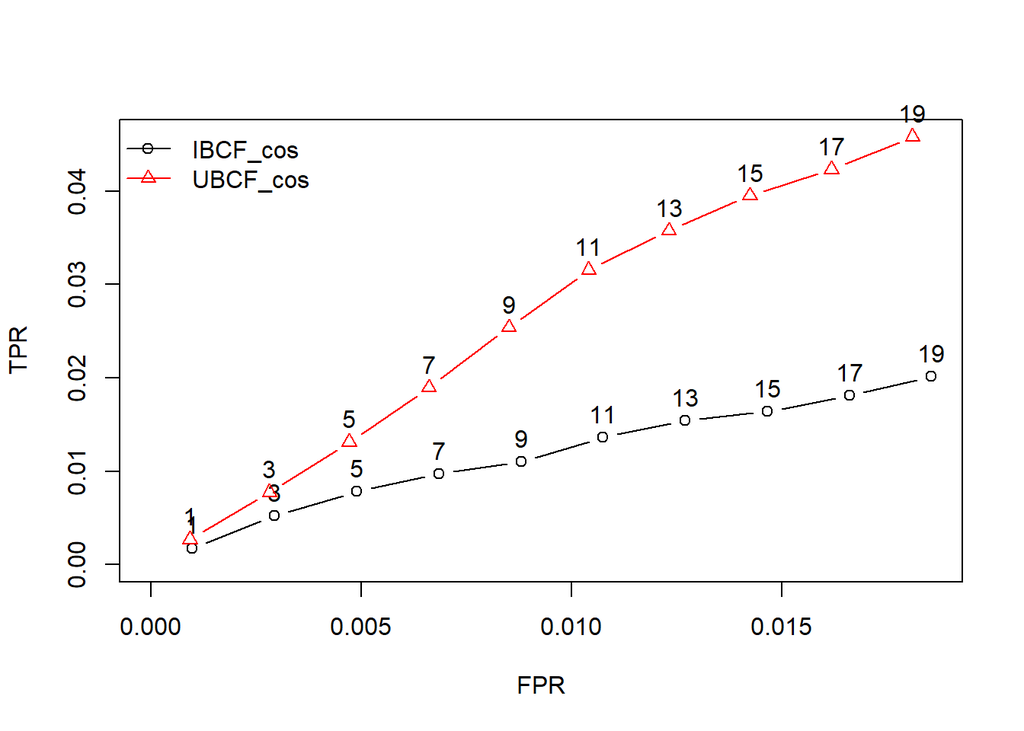

```r
#Making ROC curve
plot(eval_results, annotate = 1:2, legend="topleft")
```

As we can see UBCF model do better than IBCF models.

## Cross validation - 5 Fold

```r
#Making evaluation data set with 5 fold
eval_cv <- evaluationScheme(real_matrix, method="cross-validation",k=5,  given = 10, goodRating = 3)

#Evaluation
eval_results1 <- evaluate(x = eval_cv, method = models,n=seq(1,19,2))
```

```
## IBCF run fold/sample [model time/prediction time]
##   1  [27.84sec/1.06sec]
##   2  [27.12sec/0.52sec]
##   3  [26.9sec/0.73sec]
##   4  [23.53sec/0.61sec]
##   5  [19.14sec/0.64sec]
## UBCF run fold/sample [model time/prediction time]
##   1  [0.09sec/21.11sec]
##   2  [0.05sec/26.1sec]
##   3  [0.12sec/31.7sec]
##   4  [0.01sec/37.6sec]
##   5  [0.06sec/34.73sec]
```

```r
#Printing model performance
print(eval_results1$IBCF_cos@results[[1]])
```

```
## An object of class "confusionMatrix"
## Slot "cm":
##            TP         FP       FN       TN  precision      recall
## 1  0.03801843  0.9619816 30.20622 978.7938 0.03801843 0.001917862
## 3  0.10368664  2.8951613 30.14055 976.8606 0.03456221 0.003885521
## 5  0.18548387  4.8110599 30.05876 974.9447 0.03709677 0.007050948
## 7  0.25691244  6.7361751 29.98733 973.0196 0.03670178 0.008783895
## 9  0.30875576  8.6762673 29.93548 971.0795 0.03430620 0.010241693
## 11 0.35944700 10.6094470 29.88479 969.1463 0.03268747 0.013174333
## 13 0.41129032 12.5299539 29.83295 967.2258 0.03169653 0.014589331
## 15 0.46082949 14.4458525 29.78341 965.3099 0.03081623 0.016369662
## 17 0.50806452 16.3640553 29.73618 963.3917 0.03000752 0.019760047
## 19 0.55529954 18.2776498 29.68894 961.4781 0.02937619 0.021034222
##            TPR          FPR
## 1  0.001917862 0.0009824201
## 3  0.003885521 0.0029560155
## 5  0.007050948 0.0049098234
## 7  0.008783895 0.0068740609
## 9  0.010241693 0.0088549236
## 11 0.013174333 0.0108290645
## 13 0.014589331 0.0127899170
## 15 0.016369662 0.0147463246
## 17 0.019760047 0.0167059223
## 19 0.021034222 0.0186605950
##
## Slot "model":
## NULL
```

```r
print(eval_results1$UBCF_cos@results[[1]])
```

```
## An object of class "confusionMatrix"
## Slot "cm":
##           TP         FP       FN       TN  precision      recall
## 1  0.0702765  0.9297235 30.17396 978.8260 0.07027650 0.003247671
## 3  0.2315668  2.7684332 30.01267 976.9873 0.07718894 0.009811849
## 5  0.3698157  4.6301843 29.87442 975.1256 0.07396313 0.016452984
## 7  0.4988479  6.5011521 29.74539 973.2546 0.07126399 0.022300639
## 9  0.6405530  8.3594470 29.60369 971.3963 0.07117256 0.027736365
## 11 0.7603687 10.2396313 29.48387 969.5161 0.06912442 0.033968429
## 13 0.9089862 12.0910138 29.33525 967.6647 0.06992201 0.039579528
## 15 1.0230415 13.9769585 29.22120 965.7788 0.06820276 0.043710013
## 17 1.1428571 15.8571429 29.10138 963.8986 0.06722689 0.049067480
## 19 1.2672811 17.7327189 28.97696 962.0230 0.06669901 0.053361225
##            TPR          FPR
## 1  0.003247671 0.0009487711
## 3  0.009811849 0.0028226552
## 5  0.016452984 0.0047204966
## 7  0.022300639 0.0066290466
## 9  0.027736365 0.0085234656
## 11 0.033968429 0.0104408147
## 13 0.039579528 0.0123267505
## 15 0.043710013 0.0142508266
## 17 0.049067480 0.0161683362
## 19 0.053361225 0.0180809617
##
## Slot "model":
## NULL
```

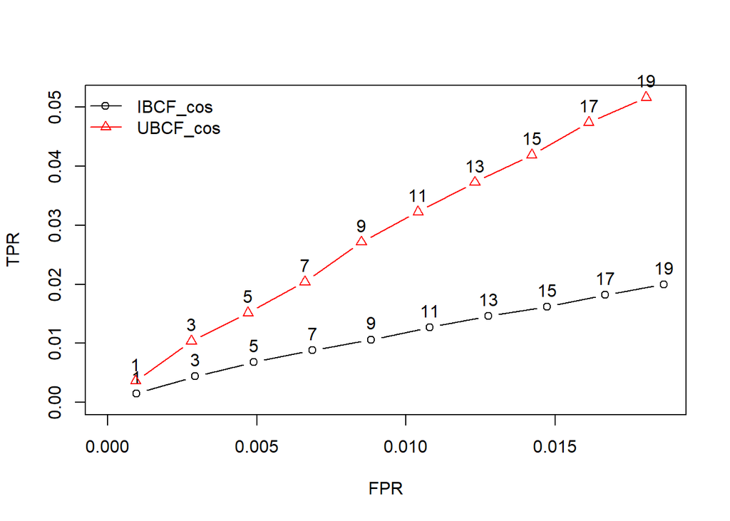

```r
#Making ROC curve
plot(eval_results1, annotate = 1:2, legend="topleft")
```

As we can see UBCF model do better than IBCF models even in cross validation approach.

```r
#Building UBCF model
Rec.model=Recommender(real_matrix,method="UBCF")

#Making Predictions
recom <- predict(Rec.model,1:dim(real_matrix)[1],data = real_matrix,n=5)

# For cokes
as(recom, "list")$cokes
```

```
## [1] "1093"  "6108"  "2751"  "50697" "2270"
```

```r
# For genog
as(recom, "list")$genog
```

```
## [1] "155"   "54904" "6076"  "57908" "43905"
```

```r
# For giblet
as(recom, "list")$giblet
```

```
## [1] "7971" "731"  "141"  "459"  "1545"
```